# Introducción a R

## Gráficas

R tiene por defecto un set de datos llamado *cars* que podemos utilizar como ejemplo en algunas funciones. Veamos el set de datos:

```r
cars
```

```
##    speed dist
## 1      4    2
## 2      4   10
## 3      7    4
## 4      7   22
## 5      8   16
## 6      9   10
## 7     10   18
## 8     10   26
## 9     10   34
## 10    11   17
## 11    11   28
## 12    12   14
## 13    12   20
## 14    12   24
```

[output cut: 36 more lines]

Podemos por ejemplo hacer un gráfico de dispersión:

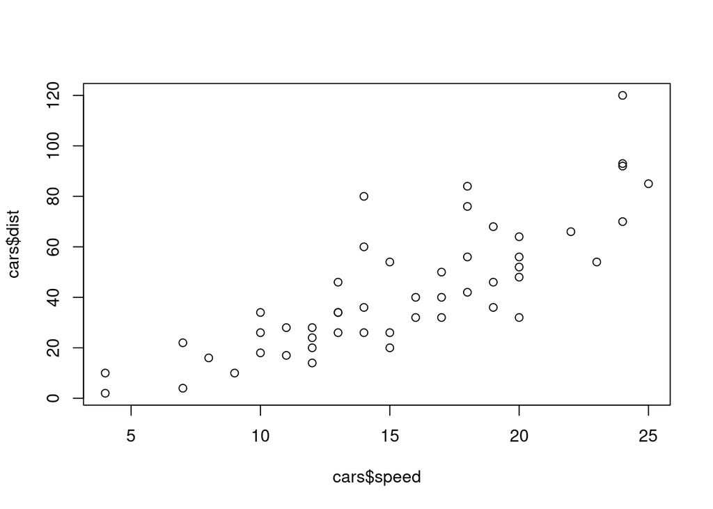

```r
plot(cars$speed, cars$dist)
```

Podemos darle un mejor formato al gráfico:

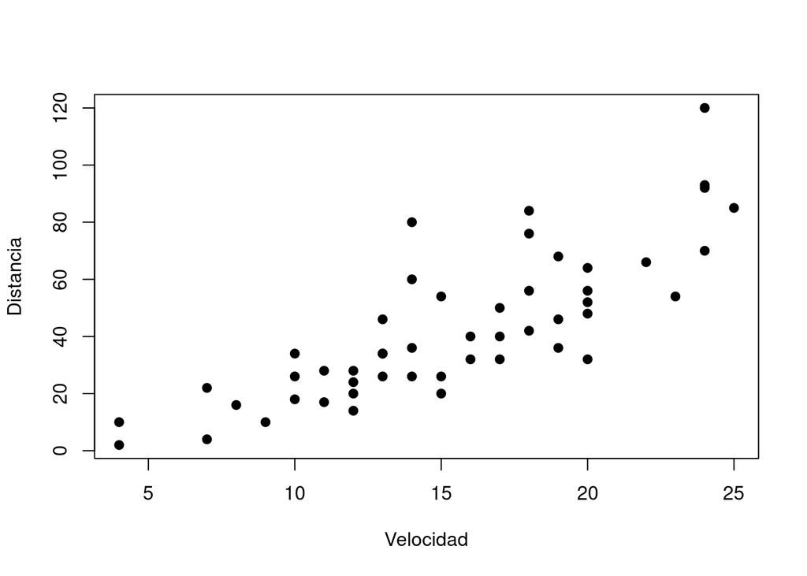

```r
plot(cars$speed, cars$dist,
     pch=19,  # Especifica qué tipo de punto se va a usar
     xlab="Velocidad",  # x label (Etiqueta del eje x)
     ylab="Distancia"   # y label (Etiqueta del eje y)
     )
```

También podemos hacer histogramas:

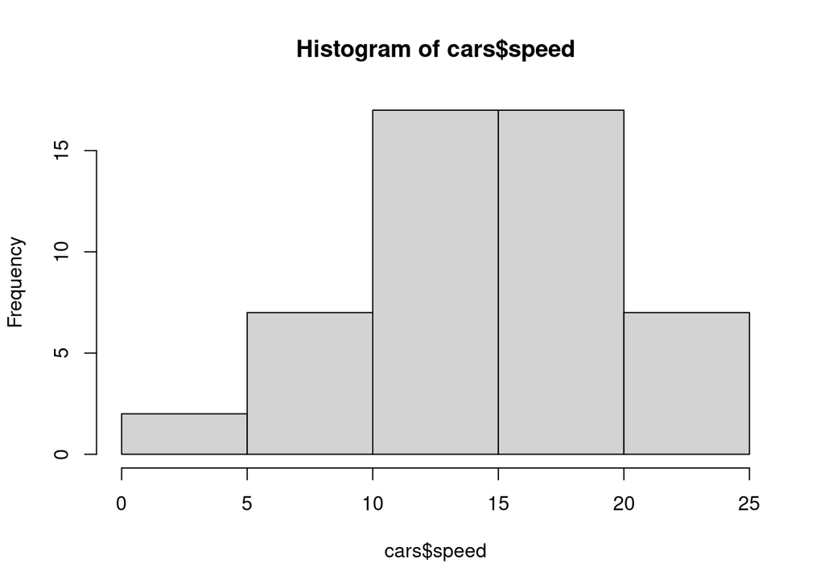

```r
hist(cars$speed)
```

Otro conjunto de datos muy famoso y que viene incorporado en R es *iris*.

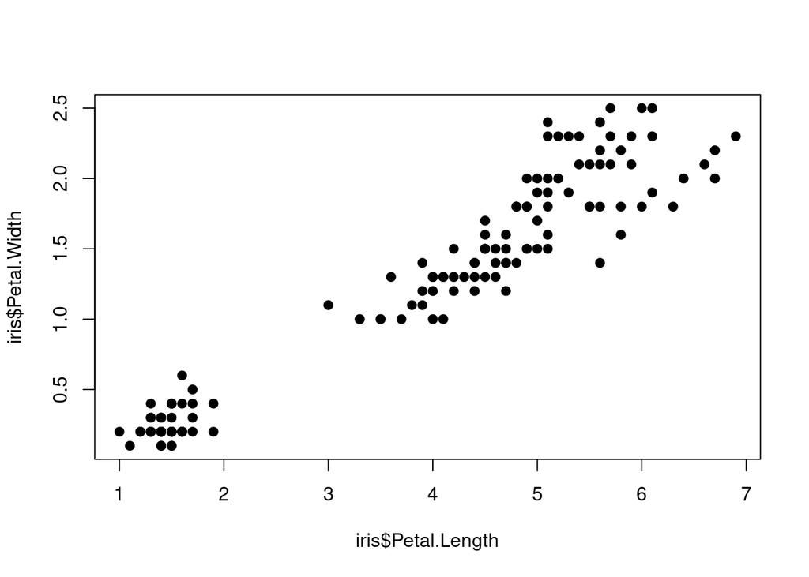

```r
plot(iris$Petal.Length, iris$Petal.Width, pch = 19)
```

Sería interesante separar los datos por especie, para eso usamos la función `dotplot` del paquete `lattice`:

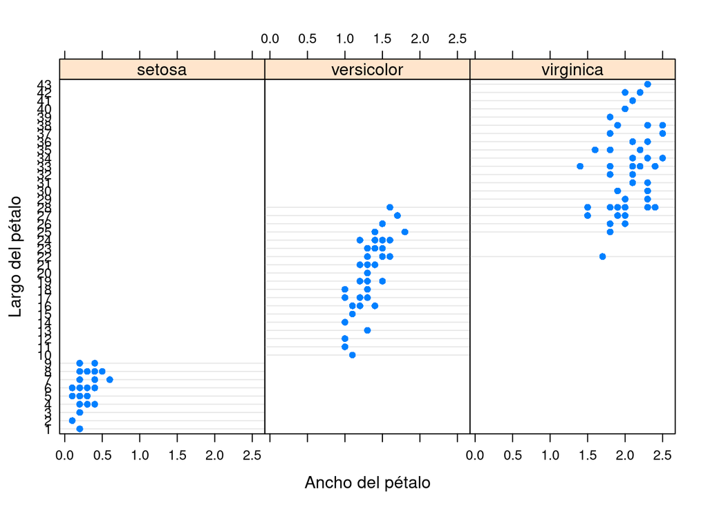

```r
library(lattice) # Cargar paquete lattice
dotplot(iris$Petal.Length ~ iris$Petal.Width | iris$Species,
        xlab = "Ancho del pétalo",
        ylab = "Largo del pétalo")
```

## Obteniendo ayuda

Para obtener más información sobre una función o un paquete tenemos varias opciones, por ejemplo usar la función `help`:

```r
help("lattice")
```

O el símbolo `?`:

```r
?lattice
```

Si necesitamos obtener información más técnica sobre un paquete podemos usar el siguiente comando:

```r
library(help = 'lattice')
```

Algunos paquetes tienen una ayuda adicional, como un pequeño tutorial, y lo podemos ver con la función `vignette`:

```r
vignette("phyloseq-basics")
```

Para obtener ayuda sobre algunos caracteres especiales los ponemos entre dos comillas invertidas:

```r
?`+`
```

También podemos ver ejemplos en algunos casos:

```r
example(plot)
```

También se puede buscar una palabra clave:

```r
help.search("network")
```

Esto último es equivalente a:

```r
??network
```

## Instalando paquetes

Para instalar paquetes se usa la función `install.packages`, por ejemplo:

```r
install.packages('ggplot')
```